# Propensity Score Matching|LAB Session

Alberto Stefanelli and Prof. Sharon Gilad

# Setting up R

## Why R

- Free and open source (think of science in developing countries)
- Good online-documentation (much better than some commercial softwere such as Mplus)
- Lively community of users (forums etc.)
- Visualization capabilities (ggplot …)
- Cooperates with other programs and programming language (e.g. Python, )
- Popularity (See popularity statistics on books, blogs, forums)
- RStudio as powerful integrated development environment (IDE) for R
- Evolves into a scientific work suite optimizing workflow (replication, reproducability etc.)
- Institutions/people (Gary King, Andrew Gelman etc.)
- Economic power (Revolution Analytics, Microsoft R Open)

## Where to study it

- If you haven’t used R sofar it’s necessary that you learn some basics in R.
- Data Camp (free trial but it is commercial)
- Try R: A short interactive intro to the language can be found here: http://tryr.codeschool.com/
- Swirl: Learn R interactively within R itself: http://swirlstats.com/
- Akos Mate ECPR R basic for the next 2 months https://github.com/aakosm/R_Basics_ECPR

## Install R on your Machine

Below some notes on the installation and setup of R and relevant packages on your own computer:

- Install Rtools for Windows machines from CRAN (https://cran.r-project.org/bin/windows/Rtools/).
- If you are using OS X, you will need to to install XCode, available for free from the App Store. This will install a compiler (if you don’t have a compiler installed) which will be needed when installing packages from GitHub that require compilation from C++ source code.
- Install the latest version of R from CRAN (https://cran.r-project.org/).
- Install the latest version of RStudio (https://www.rstudio.com/products/RStudio/). RStudio is the editor we’ll rely on, i.e. we’ll write code in RStudio which is subsequently sent to and run within R.
- Install the latest versions of various packages that we need. You can also update your packages by running “update.packages(ask = FALSE)” in the R commandline.

```r
# A function to install the required packages
# you don't need to understand what it does
ipak <- function(pkg){
  new.pkg <- pkg[!(pkg %in% installed.packages()[, "Package"])]
  if (length(new.pkg))
    install.packages(new.pkg, dependencies = TRUE,repos = c(
  CRAN = 'https://cran.rstudio.com',
  CRANextra = 'https://macos.rbind.io'
)
      )
  sapply(pkg, require, character.only = TRUE)
}


packages_needed <- c("foreign",
                     "readr",
                     "plyr",
                     "dplyr",
                     "tidyr",
                     "tibble",
                     "knitr",
                     "printr",
                     "stargazer",
                     "ggplot2",
                     "MatchIt",
                     "rmarkdown",
                     "repmis")

ipak(packages_needed)
```

```
##   foreign     readr      plyr     dplyr     tidyr    tibble     knitr    printr
##      TRUE      TRUE      TRUE      TRUE      TRUE      TRUE      TRUE      TRUE
## stargazer   ggplot2   MatchIt rmarkdown    repmis
##      TRUE      TRUE      TRUE      TRUE      TRUE
```

```r
  # Data import
    library(foreign)
    library(haven)
    library(readr)

  # Data management
    library(plyr)
    library(dplyr)
    library(tidyr)
    library(tibble)
    library(reshape2)
    library(tidyselect)
    library(knitr)
    library(repmis)
  # Visualization
    library(ggplot2)
    library(stargazer)
  # Report
    library(report)
  # Matching
    library(MatchIt)
```

# Example with the ladone dataset:

## Lalonde: Dataset description

- Analyzed in Lalonde (1986) and Dehejia and Wahba (1999).
- The “treatment” refers to participation in a employment program (RCT) that took place between 1976 and 1977 to help disadvantage to move into the labour market
- The “control” is non-randomized individuals with supposedly same characteristics
- Employment program (Treatment) -> Earnings
- DV:
  - re78: real earnings in 1978.
- Control/Treatment:
  - treat: treatment indicator
- Background and Pretreatment variables
  - age: age in years.
  - educ: years of schooling.
  - nodegr: indicator variable for high school diploma.
  - black: indicator variable for blacks.
  - hisp: indicator variable for Hispanics.
  - married: indicator variable for martial status.
  - re74: real earnings in 1974.
  - re75: real earnings in 1975.
  - u74: unemployment status 1974.
  - u75: unemployment status 1975.
- Sample of 614
- Treatment of 185
- Control of 429

## Ladone: Variables Descriptives

```r
data(lalonde) # lalonde data. It is contained in the MatchIt Package
report_lalonde <- report(lalonde) %>% to_table() # generate a descriptive report
report_lalonde
```

|  | Variable | n_Obs | Mean | SD | Min | Max | n_Missing |
| --- | --- | --- | --- | --- | --- | --- | --- |
| 2 | treat | 614 | 0.3013029 | 0.4591981 | 0 | 1.00 | 0 |
| 7 | age | 614 | 27.3631922 | 9.8811872 | 16 | 55.00 | 0 |
| 6 | educ | 614 | 10.2687296 | 2.6283247 | 0 | 18.00 | 0 |
| 3 | black | 614 | 0.3957655 | 0.4894132 | 0 | 1.00 | 0 |
| 1 | hispan | 614 | 0.1172638 | 0.3219967 | 0 | 1.00 | 0 |
| 4 | married | 614 | 0.4153094 | 0.4931771 | 0 | 1.00 | 0 |
| 5 | nodegree | 614 | 0.6302932 | 0.4831189 | 0 | 1.00 | 0 |
| 9 | re74 | 614 | 4557.5465694 | 6477.9644787 | 0 | 35040.07 | 0 |
| 8 | re75 | 614 | 2184.9382071 | 3295.6790431 | 0 | 25142.24 | 0 |
| 10 | re78 | 614 | 6792.8344830 | 7470.7307921 | 0 | 60307.93 | 0 |

##Ladone: Plot Distribution - AGE

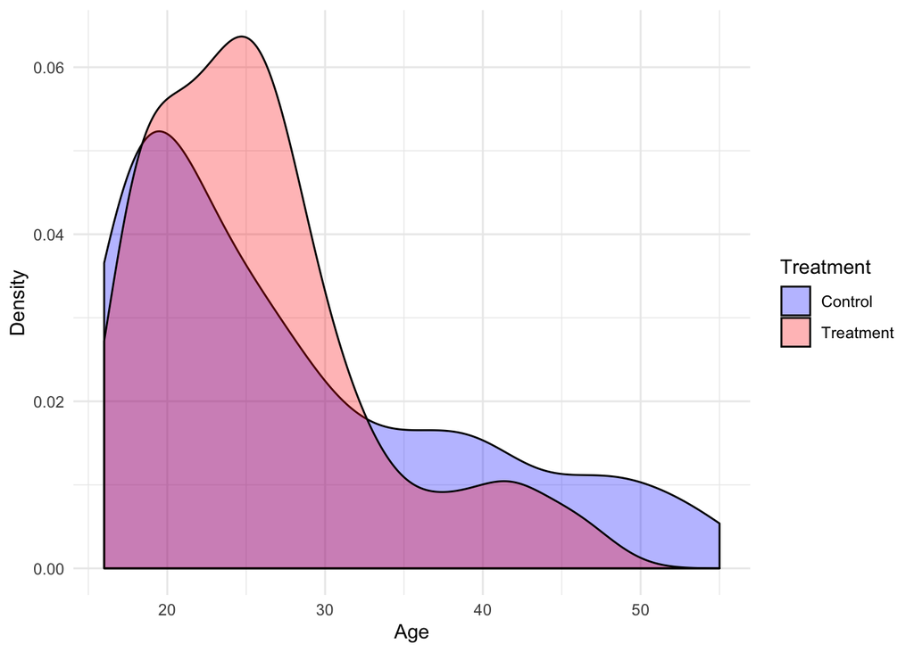

```r
lalonde$treat <- as.factor(lalonde$treat) # we recode treatment as a factor level
ggplot(lalonde, aes(x=age, fill=treat)) + # the variable to plot
  geom_density(alpha=.3)+ # the geometry
  labs(x="Age", y="Density", fill="Treatment") + # the labels of the axes
  scale_fill_manual(labels = c("Control", "Treatment"),  #labels of the legend
    values = c("blue", "red")) + #colours
    theme_minimal()
```

```r
treatment <- lalonde[lalonde$treat==1,] # subset the treatment observations
control <- lalonde[lalonde$treat==0,] # subset the control observations

t.test(treatment$age,control$age) %>% #t test treatment VS control
  report()  -> r_age # generate report


print(r_age, width=60)
```

```
## The Welch Two Sample t-test suggests that the difference
## between treatment$age and control$age (mean of x = 25.82,
## mean of y = 28.03, difference = -2.21) is significant
## (t(510.57) = -2.99, 95% CI [-3.67, -0.76], p = 0.003).
```

## Ladone: Education Distribution

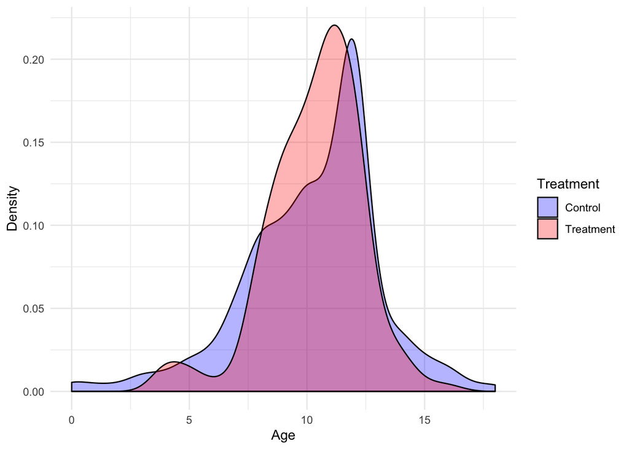

```r
ggplot(lalonde, aes(x=educ, fill=treat)) + geom_density(alpha=.3)+
  labs(x="Age", y="Density", fill="Treatment") +
  scale_fill_manual(labels = c("Control", "Treatment"), values = c("blue", "red"))+
  theme_minimal()
```

```r
t.test(treatment$educ,control$educ) %>%
  report() -> r_edu

print(r_edu, width=60)
```

```
## The Welch Two Sample t-test suggests that the difference
## between treatment$educ and control$educ (mean of x = 10.35,
## mean of y = 10.24, difference = 0.11) is not significant
## (t(485.37) = 0.55, 95% CI [-0.29, 0.51], p = 0.585).
```

## Ladone: Exact Matching

1. The simplest version of matching is exact.
2. Match each treated unit to all possible control units with exactly the same values on all the covariates
3. Creates subclasses such that within each subclass all units (treatment and control) have the same covariate values.
4. It’s indicated when your control is bigger than the treatment
5. Control and treatment groups are quite similar

```r
exact <- matchit(treat ~  age + educ + black + hispan + married + nodegree + re74 + re75,
  data = lalonde,
  method = "exact")

summary(exact,interactions = TRUE)
```

```
##
## Call:
## matchit(formula = treat ~ age + educ + black + hispan + married +
##     nodegree + re74 + re75, data = lalonde, method = "exact")
##
## Sample sizes:
##           Control Treated
## All           429     185
## Matched        12      13
## Discarded     417     172
##
## Matched sample sizes by subclass:
##   Treated Control Total
## 1       1       1     2
## 2       1       2     3
## 3       4       2     6
## 4       1       2     3
## 5       3       2     5
## 6       2       2     4
## 7       1       1     2
```

- Very few observation have been matched
- 12 for the control
- 13 for the treated
- Probably not what we want
- Let’s try something else

## Ladone: Nearest Neighbor Matching

1. Select a number of controls that best matches each individual in the treatment group
2. It uses a distance measure based on a predicted propensity score (default=logit)

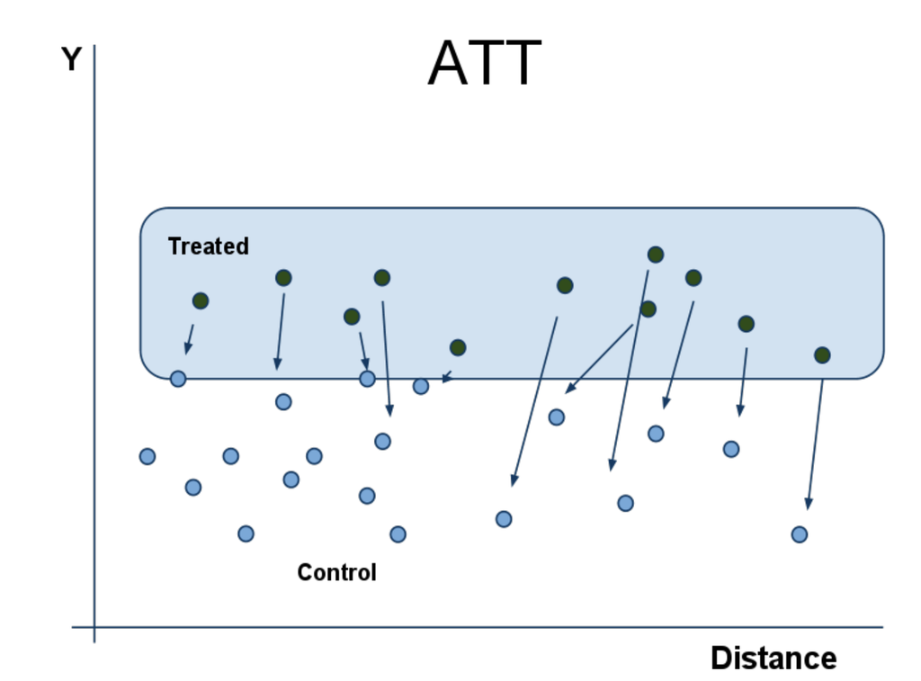

Nearest (and optimal) matching

```r
nearest <- matchit(treat ~  age + educ + black + hispan + married + nodegree + re74 + re75,
  data = lalonde, # the data
  method = "nearest") # the matching method

reteined_units <- summary(nearest)$nn

kable(reteined_units,digits=2)
```

|  | Control | Treated |
| --- | --- | --- |
| All | 429 | 185 |
| Matched | 185 | 185 |
| Unmatched | 244 | 0 |
| Discarded | 0 | 0 |

- Many more retained units (185 per each group)
- Let’s look at the imbalance

## Imbalance pre-matching

```r
sample <- summary(nearest)$sum.all # the entire unbalanced sample
kable(sample,digits=2)
```

|  | Means Treated | Means Control | SD Control | Mean Diff | eQQ Med | eQQ Mean | eQQ Max |
| --- | --- | --- | --- | --- | --- | --- | --- |
| distance | 0.58 | 0.18 | 0.23 | 0.40 | 0.52 | 0.40 | 0.60 |
| age | 25.82 | 28.03 | 10.79 | -2.21 | 1.00 | 3.26 | 10.00 |
| educ | 10.35 | 10.24 | 2.86 | 0.11 | 1.00 | 0.70 | 4.00 |
| black | 0.84 | 0.20 | 0.40 | 0.64 | 1.00 | 0.64 | 1.00 |
| hispan | 0.06 | 0.14 | 0.35 | -0.08 | 0.00 | 0.08 | 1.00 |
| married | 0.19 | 0.51 | 0.50 | -0.32 | 0.00 | 0.32 | 1.00 |
| nodegree | 0.71 | 0.60 | 0.49 | 0.11 | 0.00 | 0.11 | 1.00 |
| re74 | 2095.57 | 5619.24 | 6788.75 | -3523.66 | 2425.57 | 3620.92 | 9216.50 |
| re75 | 1532.06 | 2466.48 | 3292.00 | -934.43 | 981.10 | 1060.66 | 6795.01 |

## Imbalance post-matching

```r
matched <- summary(nearest)$sum.matched # the matched  sample

kable(matched,digits=2)
```

|  | Means Treated | Means Control | SD Control | Mean Diff | eQQ Med | eQQ Mean | eQQ Max |
| --- | --- | --- | --- | --- | --- | --- | --- |
| distance | 0.58 | 0.36 | 0.25 | 0.21 | 0.16 | 0.21 | 0.45 |
| age | 25.82 | 25.30 | 10.59 | 0.51 | 3.00 | 3.39 | 9.00 |
| educ | 10.35 | 10.61 | 2.66 | -0.26 | 0.00 | 0.45 | 3.00 |
| black | 0.84 | 0.47 | 0.50 | 0.37 | 0.00 | 0.37 | 1.00 |
| hispan | 0.06 | 0.22 | 0.41 | -0.16 | 0.00 | 0.16 | 1.00 |
| married | 0.19 | 0.21 | 0.41 | -0.02 | 0.00 | 0.02 | 1.00 |
| nodegree | 0.71 | 0.64 | 0.48 | 0.07 | 0.00 | 0.07 | 1.00 |
| re74 | 2095.57 | 2342.11 | 4238.98 | -246.53 | 131.27 | 545.12 | 13121.75 |
| re75 | 1532.06 | 1614.75 | 2632.35 | -82.69 | 152.18 | 349.54 | 11365.71 |

## Imbalance reduction

```r
imbalance_reduction <- summary(nearest)$reduction
kable(imbalance_reduction,digits=2)
```

|  | Mean Diff. | eQQ Med | eQQ Mean | eQQ Max |
| --- | --- | --- | --- | --- |
| distance | 45.71 | 68.19 | 45.75 | 24.70 |
| age | 76.81 | -200.00 | -3.81 | 10.00 |
| educ | -134.77 | 100.00 | 35.38 | 25.00 |
| black | 41.76 | 100.00 | 42.02 | 0.00 |
| hispan | -89.48 | 0.00 | -93.33 | 0.00 |
| married | 93.32 | 0.00 | 93.33 | 0.00 |
| nodegree | 36.90 | 0.00 | 38.10 | 0.00 |
| re74 | 93.00 | 94.59 | 84.95 | -42.37 |
| re75 | 91.15 | 84.49 | 67.05 | -67.27 |